# Superstore Analysis_Different_Clusters

## Superstore Sales Analysis Machine Learning With Different Clusters

```python
import pandas as pd
import numpy as np
import seaborn as sns
import matplotlib.pyplot as plt

from sklearn.decomposition import PCA
from sklearn.preprocessing import StandardScaler
from sklearn.cluster import KMeans
from sklearn.cluster import DBSCAN
from scipy.cluster.hierarchy import linkage, dendrogram
from sklearn.cluster import KMeans, DBSCAN, AgglomerativeClustering
from sklearn.metrics import silhouette_score
```

```python
## Surpress the Warnings
import warnings
warnings.filterwarnings('ignore')
```

```python
## Visualisation
from matplotlib.pyplot import xticks
%matplotlib inline
```

```python
## Data Display Customization
pd.set_option('display.max_rows', None)
pd.set_option('display.max_columns', None)
```

Loading Data From CSV File

```python
# Importing the Dataframe
sv = pd.read_csv('superstore_sales.csv')
```

```python
# Display basic info
sv.head()
```

|  | Order ID | Order Date | Order Priority | Order Quantity | Sales | Discount | Ship Mode | Profit | Unit Price | Shipping Cost | Customer Name | Province | Region | Customer Segment | Product Category | Product Sub-Category | Product Base Margin | Ship Date |
| --- | --- | --- | --- | --- | --- | --- | --- | --- | --- | --- | --- | --- | --- | --- | --- | --- | --- | --- |
| 0 | 3 | 13-10-2010 | Low | 6 | 261.5400 | 0.04 | Regular Air | -213.25 | 38.94 | 35.00 | Muhammed MacIntyre | Nunavut | Nunavut | Small Business | Office Supplies | Storage & Organization | 0.80 | 20-10-2010 |
| 1 | 293 | 01-10-2012 | High | 49 | 10123.0200 | 0.07 | Delivery Truck | 457.81 | 208.16 | 68.02 | Barry French | Nunavut | Nunavut | Consumer | Office Supplies | Appliances | 0.58 | 02-10-2012 |
| 2 | 293 | 01-10-2012 | High | 27 | 244.5700 | 0.01 | Regular Air | 46.71 | 8.69 | 2.99 | Barry French | Nunavut | Nunavut | Consumer | Office Supplies | Binders and Binder Accessories | 0.39 | 03-10-2012 |
| 3 | 483 | 10-07-2011 | High | 30 | 4965.7595 | 0.08 | Regular Air | 1198.97 | 195.99 | 3.99 | Clay Rozendal | Nunavut | Nunavut | Corporate | Technology | Telephones and Communication | 0.58 | 12-07-2011 |
| 4 | 515 | 28-08-2010 | Not Specified | 19 | 394.2700 | 0.08 | Regular Air | 30.94 | 21.78 | 5.94 | Carlos Soltero | Nunavut | Nunavut | Consumer | Office Supplies | Appliances | 0.50 | 30-08-2010 |

```python
sv.info()
```

```
<class 'pandas.core.frame.DataFrame'>
RangeIndex: 8399 entries, 0 to 8398
Data columns (total 18 columns):
 #   Column                Non-Null Count  Dtype
---  ------                --------------  -----
 0   Order ID              8399 non-null   int64
 1   Order Date            8399 non-null   object
 2   Order Priority        8399 non-null   object
 3   Order Quantity        8399 non-null   int64
 4   Sales                 8399 non-null   float64
 5   Discount              8399 non-null   float64
 6   Ship Mode             8399 non-null   object
 7   Profit                8399 non-null   float64
 8   Unit Price            8399 non-null   float64
 9   Shipping Cost         8399 non-null   float64
 10  Customer Name         8399 non-null   object
 11  Province              8399 non-null   object
 12  Region                8399 non-null   object
 13  Customer Segment      8399 non-null   object
 14  Product Category      8399 non-null   object
 15  Product Sub-Category  8399 non-null   object
 16  Product Base Margin   8336 non-null   float64
 17  Ship Date             8399 non-null   object
dtypes: float64(6), int64(2), object(10)
memory usage: 1.2+ MB
```

```python
# Check Unique Region
sv['Region'].unique()
```

```
array(['Nunavut', 'Northwest Territories', 'Atlantic', 'Prarie', 'West',
       'Ontario', 'Quebec', 'Yukon'], dtype=object)
```

## Data Preprocessing

Select relevant features (e.g., Sales, Profit, Quantity, Discount, Customer Segment)

Handle missing values (if any)

Standardize numerical variables (for distance-based clustering)

```python
# Select numeric features
features = ["Sales", "Profit", "Order Quantity", "Discount"]
sv_selected = sv[features]

# Handle missing values
sv_selected = sv_selected.dropna()

# Scale data
scaler = StandardScaler()
sv_scaled = scaler.fit_transform(sv_selected)
```

```python
# Check for Missing Values

print(sv.isnull().sum())
```

```
Order ID                 0
Order Date               0
Order Priority           0
Order Quantity           0
Sales                    0
Discount                 0
Ship Mode                0
Profit                   0
Unit Price               0
Shipping Cost            0
Customer Name            0
Province                 0
Region                   0
Customer Segment         0
Product Category         0
Product Sub-Category     0
Product Base Margin     63
Ship Date                0
dtype: int64
```

```python
features = ["Sales", "Profit", "Order Quantity", "Discount"]
sv_selected = sv[features].copy()  # Use .copy() to avoid SettingWithCopyWarning

# Display first few rows to verify selection
print(sv_selected.head())
```

```
        Sales   Profit  Order Quantity  Discount
0    261.5400  -213.25               6      0.04
1  10123.0200   457.81              49      0.07
2    244.5700    46.71              27      0.01
3   4965.7595  1198.97              30      0.08
4    394.2700    30.94              19      0.08
```

```python
# Drop rows with missing values in selected features
sv_selected = sv_selected.dropna().reset_index(drop=True)

# Display the number of remaining rows after dropping missing values
print(f"Remaining rows after dropping missing values: {sv_selected.shape[0]}")
```

```
Remaining rows after dropping missing values: 8399
```

```python
sv.isnull().values.any()
```

```
True
```

```python
# Identify Unique Categories
for col in sv.select_dtypes(include=['object']).columns:
    print(f"{col}: {sv[col].nunique()} unique values")
```

```
Order Date: 1418 unique values
Order Priority: 5 unique values
Ship Mode: 3 unique values
Customer Name: 795 unique values
Province: 13 unique values
Region: 8 unique values
Customer Segment: 4 unique values
Product Category: 3 unique values
Product Sub-Category: 17 unique values
Ship Date: 1450 unique values
```

```python
# Check Sales & Profit Trends
print(sv.groupby("Product Category")["Sales"].sum())
print(sv.groupby("Product Category")["Profit"].sum())
```

```
Product Category
Furniture          5178590.542
Office Supplies    3752762.100
Technology         5984248.182
Name: Sales, dtype: float64
Product Category
Furniture          117433.03
Office Supplies    518021.43
Technology         886313.52
Name: Profit, dtype: float64
```

```python
# Initialize the scaler
scaler = StandardScaler()

# Fit and transform the selected features
sv_scaled = scaler.fit_transform(sv_selected)

# Convert back to DataFrame for better readability
sv_scaled_df = pd.DataFrame(sv_scaled, columns=sv_selected.columns)

# Display first few rows to verify scaling
print(sv_scaled_df.head())
```

```
      Sales    Profit  Order Quantity  Discount
0 -0.422429 -0.329634       -1.351620 -0.303930
1  2.328458  0.231180        1.617951  0.638840
2 -0.427163 -0.112382        0.098636 -1.246700
3  0.889826  0.850577        0.305815  0.953097
4 -0.385403 -0.125561       -0.453843  0.953097
```

# Sales & Profit Breakdown by Region

```python
sv.groupby("Region")[["Sales", "Profit"]].sum().sort_values("Sales", ascending=False)

# This will tell which regions contribute the most to total sales and profit.
```

| Region | Sales | Profit |
| --- | --- | --- |
| West | 3.597549e+06 | 297008.61 |
| Ontario | 3.063212e+06 | 346868.54 |
| Prarie | 2.837305e+06 | 321160.12 |
| Atlantic | 2.014248e+06 | 238960.66 |
| Quebec | 1.510195e+06 | 140426.65 |
| Yukon | 9.758674e+05 | 73849.21 |
| Northwest Territories | 8.008473e+05 | 100653.08 |
| Nunavut | 1.163765e+05 | 2841.11 |

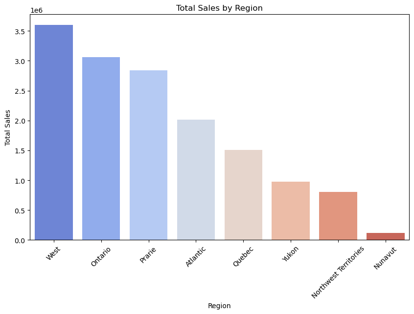

```python
# Calculate the sum of Sales and Profit for each Region
region_summary = sv.groupby("Region")[["Sales", "Profit"]].sum().sort_values("Sales", ascending=False)

# Plot the total Sales per Region with a different color palette
plt.figure(figsize=(10, 6))
sns.barplot(x=region_summary.index, y=region_summary["Sales"], palette="coolwarm")  # Custom color palette
plt.title('Total Sales by Region')
plt.xlabel('Region')
plt.ylabel('Total Sales')
plt.xticks(rotation=45)
plt.show()
```

# Sales & Profit Breakdown by Customer Segment

```python
sv.groupby("Customer Segment")[["Sales", "Profit"]].sum().sort_values("Profit", ascending=False)

# This helps in targeting high-value customer groups for promotions.
```

| Customer Segment | Sales | Profit |
| --- | --- | --- |
| Corporate | 5.498905e+06 | 599746.00 |
| Home Office | 3.564764e+06 | 318354.03 |
| Small Business | 2.788321e+06 | 315708.01 |
| Consumer | 3.063611e+06 | 287959.94 |

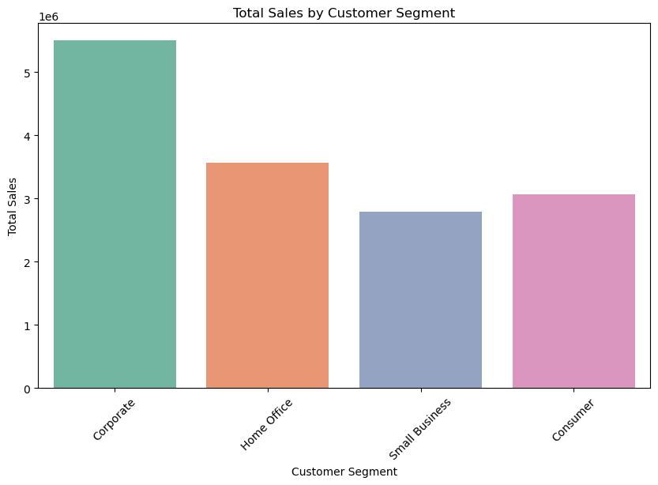

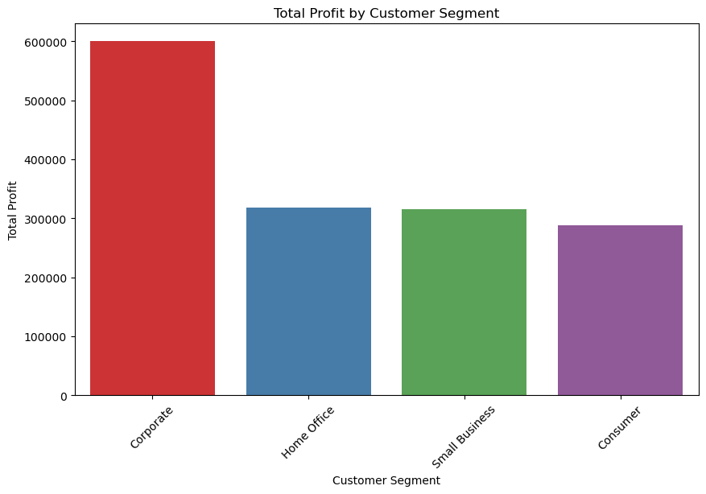

```python
# Calculate the sum of Sales and Profit for each Customer Segment
segment_summary = sv.groupby("Customer Segment")[["Sales", "Profit"]].sum().sort_values("Profit", ascending=False)

# Plot the total Sales per Customer Segment with a bright color palette
plt.figure(figsize=(10, 6))
sns.barplot(x=segment_summary.index, y=segment_summary["Sales"], palette="Set2")  # Brighter color palette
plt.title('Total Sales by Customer Segment')
plt.xlabel('Customer Segment')
plt.ylabel('Total Sales')
plt.xticks(rotation=45)
plt.show()

# Plot the total Profit per Customer Segment with a bright color palette
plt.figure(figsize=(10, 6))
sns.barplot(x=segment_summary.index, y=segment_summary["Profit"], palette="Set1")  # Brighter color palette
plt.title('Total Profit by Customer Segment')
plt.xlabel('Customer Segment')
plt.ylabel('Total Profit')
plt.xticks(rotation=45)
plt.show()
```

# Profitability Across Product Categories by Region

```python
sv.pivot_table(index="Region", columns="Product Category", values="Profit", aggfunc="sum")

# This will help identify which regions perform best in each product category
```

| Product Category Region | Furniture | Office Supplies | Technology |
| --- | --- | --- | --- |
| Atlantic | 15345.65 | 66970.47 | 156644.54 |
| Northwest Territories | 7451.24 | 36994.06 | 56207.78 |
| Nunavut | 3478.88 | -3124.02 | 2486.25 |
| Ontario | 19886.91 | 153212.76 | 173768.87 |
| Prarie | 30551.22 | 83259.70 | 207349.20 |
| Quebec | -760.77 | 42982.17 | 98205.25 |
| West | 30924.64 | 116666.85 | 149417.12 |
| Yukon | 10555.26 | 21059.44 | 42234.51 |

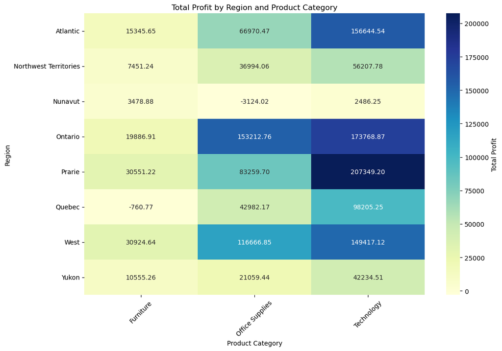

```python
# Create a pivot table for Profit by Region and Product Category
pivot_profit = sv.pivot_table(index="Region", columns="Product Category", values="Profit", aggfunc="sum")

# Plot a heatmap to visualize the pivot table
plt.figure(figsize=(12, 8))
sns.heatmap(pivot_profit, annot=True, cmap="YlGnBu", fmt=".2f", cbar_kws={'label': 'Total Profit'})
plt.title('Total Profit by Region and Product Category')
plt.xlabel('Product Category')
plt.ylabel('Region')
plt.xticks(rotation=45)
plt.yticks(rotation=0)
plt.show()
```

# Customer Segmentation Analysis

```python
print(sv.columns)
```

```
Index(['Order ID', 'Order Date', 'Order Priority', 'Order Quantity', 'Sales',
       'Discount', 'Ship Mode', 'Profit', 'Unit Price', 'Shipping Cost',
       'Customer Name', 'Province', 'Region', 'Customer Segment',
       'Product Category', 'Product Sub-Category', 'Product Base Margin',
       'Ship Date'],
      dtype='object')
```

```python
sv.columns = sv.columns.str.strip()
```

```python
print(sv.head())
```

```
   Order ID  Order Date Order Priority  Order Quantity       Sales  Discount  \
0         3  13-10-2010            Low               6    261.5400      0.04
1       293  01-10-2012           High              49  10123.0200      0.07
2       293  01-10-2012           High              27    244.5700      0.01
3       483  10-07-2011           High              30   4965.7595      0.08
4       515  28-08-2010  Not Specified              19    394.2700      0.08

        Ship Mode   Profit  Unit Price  Shipping Cost       Customer Name  \
0     Regular Air  -213.25       38.94          35.00  Muhammed MacIntyre
1  Delivery Truck   457.81      208.16          68.02        Barry French
2     Regular Air    46.71        8.69           2.99        Barry French
3     Regular Air  1198.97      195.99           3.99       Clay Rozendal
4     Regular Air    30.94       21.78           5.94      Carlos Soltero

  Province   Region Customer Segment Product Category  \
0  Nunavut  Nunavut   Small Business  Office Supplies
1  Nunavut  Nunavut         Consumer  Office Supplies
2  Nunavut  Nunavut         Consumer  Office Supplies
3  Nunavut  Nunavut        Corporate       Technology
4  Nunavut  Nunavut         Consumer  Office Supplies

             Product Sub-Category  Product Base Margin   Ship Date
0          Storage & Organization                 0.80  20-10-2010
1                      Appliances                 0.58  02-10-2012
2  Binders and Binder Accessories                 0.39  03-10-2012
3    Telephones and Communication                 0.58  12-07-2011
4                      Appliances                 0.50  30-08-2010
```

```python
from sklearn.cluster import KMeans

# Create an instance of the KMeans class
kmeans = KMeans(n_clusters=3)  # Set the number of clusters as needed

# Fit the model and assign cluster labels
sv["Cluster_Label"] = kmeans.fit_predict(sv[["Sales", "Profit"]])
```

```python
print(sv["Cluster_Label"].unique())
```

```
[0 2 1]
```

```python
sv["Cluster_Label"] = pd.to_numeric(sv["Cluster_Label"], errors="coerce")
```

```python
sv.groupby("Cluster_Label")[["Sales", "Profit"]].mean()

# This tells us which customer clusters spend the most and how they behave.
```

| Cluster_Label | Sales | Profit |
| --- | --- | --- |
| 0 | 687.328610 | -10.162642 |
| 1 | 19257.490565 | 4314.891623 |
| 2 | 6385.726671 | 785.192393 |

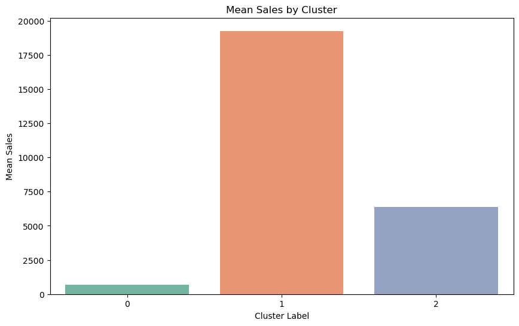

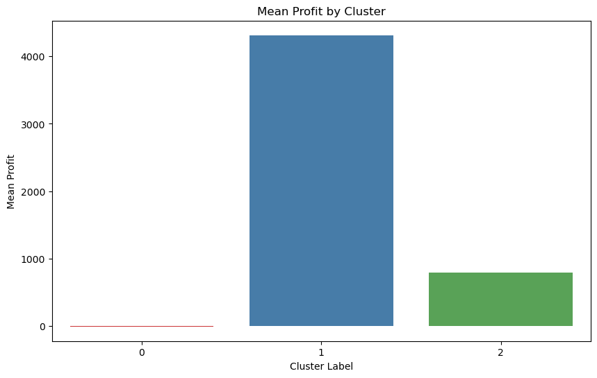

```python
# Calculate the mean Sales and Profit for each Cluster_Label
cluster_summary = sv.groupby("Cluster_Label")[["Sales", "Profit"]].mean()

# Plot the mean Sales per Cluster_Label
plt.figure(figsize=(10, 6))
sns.barplot(x=cluster_summary.index, y=cluster_summary["Sales"], palette="Set2")  # Bright color palette
plt.title('Mean Sales by Cluster')
plt.xlabel('Cluster Label')
plt.ylabel('Mean Sales')
plt.xticks(rotation=0)
plt.show()

# Plot the mean Profit per Cluster_Label
plt.figure(figsize=(10, 6))
sns.barplot(x=cluster_summary.index, y=cluster_summary["Profit"], palette="Set1")  # Bright color palette
plt.title('Mean Profit by Cluster')
plt.xlabel('Cluster Label')
plt.ylabel('Mean Profit')
plt.xticks(rotation=0)
plt.show()
```

# Apply Different Clustering Techniques

1. K-Means Clustering

```python
# Define number of clusters (elbow method can help)
kmeans = KMeans(n_clusters=3, random_state=42)
sv["KMeans_Cluster"] = kmeans.fit_predict(sv_scaled)
```

2. DBSCAN (Density-Based Clustering)

```python
dbscan = DBSCAN(eps=0.7, min_samples=5)
sv["DBSCAN_Cluster"] = dbscan.fit_predict(sv_scaled)
```

3. Hierarchical Clustering

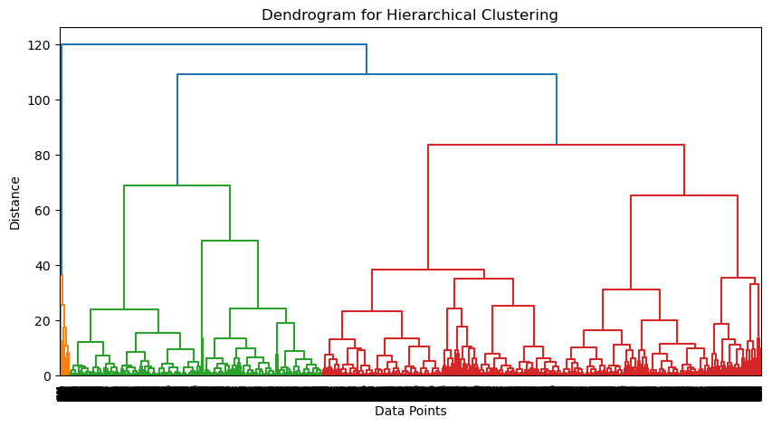

```
Hierarchical_Cluster
0    5244
2    3037
1     118
Name: count, dtype: int64
```

```python
linkage_matrix = linkage(sv_scaled, method='ward')

# Plot Dendrogram
plt.figure(figsize=(10, 5))
dendrogram(linkage_matrix)
plt.title("Dendrogram for Hierarchical Clustering")
plt.xlabel("Data Points")
plt.ylabel("Distance")
plt.show()

# Apply Agglomerative Clustering (choosing 3 clusters)
n_clusters = 3  # Change this based on the dendrogram
agglo = AgglomerativeClustering(n_clusters=n_clusters, linkage='ward')
sv_scaled_df["Hierarchical_Cluster"] = agglo.fit_predict(sv_scaled)

# Display first few cluster assignments
print(sv_scaled_df["Hierarchical_Cluster"].value_counts())
```

4. Silhouette Score

```python
# Calculate silhouette score for K-Means clustering
silhouette_score_kmeans = silhouette_score(sv_scaled, sv["KMeans_Cluster"])
print("Silhouette score for K-Means clustering:", silhouette_score_kmeans)

# Calculate silhouette score for DBSCAN clustering
silhouette_score_dbscan = silhouette_score(sv_scaled, sv["DBSCAN_Cluster"])
print("Silhouette score for DBSCAN clustering:", silhouette_score_dbscan)

# Calculate silhouette score for Hierarchical clustering
silhouette_score_agglo = silhouette_score(sv_scaled, sv_scaled_df["Hierarchical_Cluster"])
```

```
Silhouette score for K-Means clustering: 0.29238862845828384
Silhouette score for DBSCAN clustering: 0.406840322451176
```

# Visualizing Clusters

Compare Clustering Results: Helps compare how different clustering methods perform.

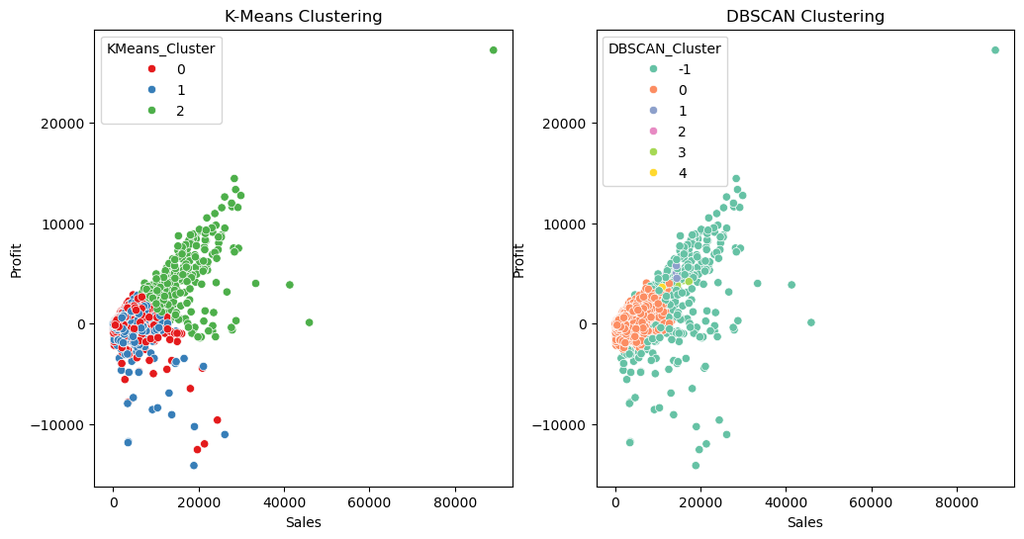

```python
plt.figure(figsize=(12,6))

# K-Means plot
plt.subplot(1,2,1)
sns.scatterplot(x=sv["Sales"], y=sv["Profit"], hue=sv["KMeans_Cluster"], palette="Set1")
plt.title("K-Means Clustering")

# DBSCAN plot
plt.subplot(1,2,2)
sns.scatterplot(x=sv["Sales"], y=sv["Profit"], hue=sv["DBSCAN_Cluster"], palette="Set2")
plt.title("DBSCAN Clustering")

plt.show()
```

# Business Insights & Recommendations

Customer Segments Identified

```python
## Cluster	                     ## Characteristics	                                   ## Business Actions
 # High-Spending Customers	        High Sales & Profit	                                  Offer VIP membership, personalized discounts
 # Regular Buyers	                Medium Sales & Profit	                              Loyalty programs, targeted ads
 # Price-Sensitive Customers	    Low Profit, high discounts	                          Special promotions, bundled offers
 # Outliers (DBSCAN -1)	            Irregular spending	                                  Investigate fraud, special monitoring
```

```python
# Save results
sv.to_csv("Superstore_Clustered.csv", index=False)
```

```python
# Apply K-Means clustering
kmeans = KMeans(n_clusters=3, random_state=42, n_init=10)
sv_scaled_df["KMeans_Cluster"] = kmeans.fit_predict(sv_scaled)

# Apply DBSCAN clustering
dbscan = DBSCAN(eps=1.5, min_samples=5)
sv_scaled_df["DBSCAN_Cluster"] = dbscan.fit_predict(sv_scaled)

# Apply Agglomerative Hierarchical clustering
agglo = AgglomerativeClustering(n_clusters=3)
sv_scaled_df["Hierarchical_Cluster"] = agglo.fit_predict(sv_scaled)

# Compute silhouette scores (ignoring DBSCAN outliers)
kmeans_silhouette = silhouette_score(sv_scaled, sv_scaled_df["KMeans_Cluster"])
agglo_silhouette = silhouette_score(sv_scaled, sv_scaled_df["Hierarchical_Cluster"])

# DBSCAN silhouette score (excluding outliers labeled as -1)
dbscan_mask = sv_scaled_df["DBSCAN_Cluster"] != -1
if dbscan_mask.sum() > 1:  # Ensure at least 2 samples exist for silhouette calculation
    dbscan_silhouette = silhouette_score(sv_scaled[dbscan_mask], sv_scaled_df["DBSCAN_Cluster"][dbscan_mask])
else:
    dbscan_silhouette = None

# Print results
print(f"K-Means Silhouette Score: {kmeans_silhouette}")
print(f"Hierarchical Clustering Silhouette Score: {agglo_silhouette}")
print(f"DBSCAN Silhouette Score: {dbscan_silhouette}")
```

```
K-Means Silhouette Score: 0.2948224734416326
Hierarchical Clustering Silhouette Score: 0.2585409728592701
DBSCAN Silhouette Score: 0.8176665880273991
```

```python
## Compare Clustering Results

# I'll print the silhouette scores for K-Means, DBSCAN, and Hierarchical clustering.

# We'll see which technique performs better based on how well it separates clusters.

## Visualize Clusters

# We'll create scatter plots for each clustering method.

# For visualization, we can use two principal components (PCA) to reduce dimensions to 2D.

# I'll run the analysis now
```

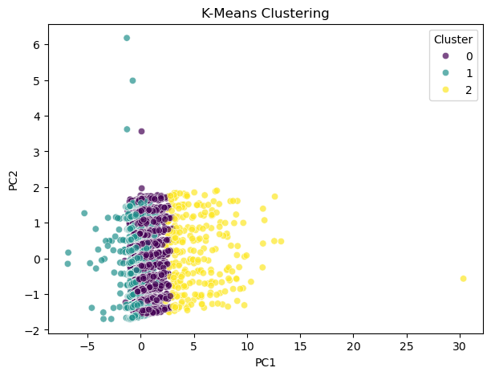

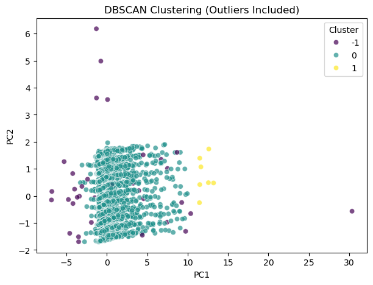

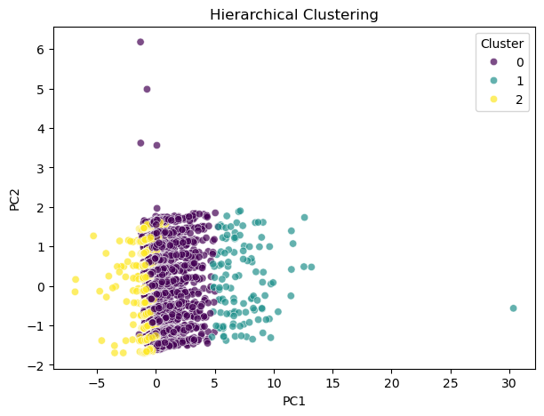

```python
# Reduce dimensions using PCA for visualization

pca = PCA(n_components=2)
sv_pca = pca.fit_transform(sv_scaled)

# Create a DataFrame with PCA results and cluster labels
pca_df = pd.DataFrame(sv_pca, columns=["PC1", "PC2"])
pca_df["KMeans_Cluster"] = sv_scaled_df["KMeans_Cluster"]
pca_df["DBSCAN_Cluster"] = sv_scaled_df["DBSCAN_Cluster"]
pca_df["Hierarchical_Cluster"] = sv_scaled_df["Hierarchical_Cluster"]

# Plot function for clustering results
def plot_clusters(cluster_col, title):
    plt.figure(figsize=(7, 5))
    sns.scatterplot(x="PC1", y="PC2", hue=cluster_col, palette="viridis", data=pca_df, alpha=0.7)
    plt.title(title)
    plt.legend(title="Cluster")
    plt.show()

# Visualize clusters for each method
plot_clusters("KMeans_Cluster", "K-Means Clustering")
plot_clusters("DBSCAN_Cluster", "DBSCAN Clustering (Outliers Included)")
plot_clusters("Hierarchical_Cluster", "Hierarchical Clustering")
```

The above generated scatter plots shows how well each clustering algorithm separates the data in a 2D space using Principal Component Analysis (PCA).

What This Code Will Do:

1. Reduce Dimensions → Uses PCA (Principal Component Analysis) to convert high-dimensional data into 2D.
2. Plot Clusters → Creates scatter plots for K-Means, DBSCAN, and Hierarchical clustering results.
3. Identify Outliers → Highlights DBSCAN outliers (assigned cluster -1).